# 3º Exercício Avaliativo Séries temporais

Ariane Hayana Thomé de Farias

06/11/2021

## Apresentação

Este relatório aborda um exemplo didático utilizando dados do mercado de ações com intuito de analisar e construir um modelo de previsão de preços de fechamento de ações para uma determinada empresa, que será intitulada de `Empresa X`.

## Conjunto de dados

A série é composta por `42` dados diários (exceto feriados e finais de semana), com início em `04/03/2020` e término em `01/05/2020`. Para ilustrar como os dados estão dispostos, é possível visualizar as seis primeiras observações do conjunto de dados, conforme tabela abaixo:

| Date | Open | High | Low | Close | Adj.Close | Volume |
| --- | --- | --- | --- | --- | --- | --- |
| 2020-03-04 | 40.72 | 41.45 | 39.80 | 41.39 | 41.00126 | 30022100 |
| 2020-03-05 | 40.17 | 40.51 | 39.29 | 39.57 | 39.19835 | 30255900 |
| 2020-03-06 | 38.00 | 39.95 | 37.80 | 39.68 | 39.30732 | 48605600 |
| 2020-03-09 | 36.90 | 39.56 | 36.29 | 37.96 | 37.60347 | 61535300 |
| 2020-03-10 | 39.25 | 40.15 | 37.87 | 40.08 | 39.70356 | 50536500 |
| 2020-03-11 | 39.02 | 39.16 | 36.37 | 37.05 | 36.70202 | 63594300 |

Diante do exposto na tabela, é possível observar que o conjunto de dados é composto pela data (`Date`), bem como a coluna `Open` representa o preço de abertura das ações naquele dia e a coluna `High` representa o preço mais alto alcançado pelas ações e `Low` o preço mais baixo. A coluna `Close` corresponde ao preço de fechamento da ação e o volume da ação é dado pela coluna `Volume`. Por fim, temos a coluna `Adj.Close` (fechamento ajustado), que representa o preço de fechamento após os ajustes para todos os desdobramentos e distribuições de dividendos aplicáveis.

## Ajustes

Para esta etapa foram selecionadas apenas as variáveis de interesse: `Date` e `Close`. Desta forma, tais variáveis foram selecionadas e transformadas de modo que o objeto `Date` foi convertido para um objeto `POSIXct` e assim, foi possível a conversão para um objeto `xts`. Após avaliações para validar as conversões necessárias, foi possível iniciar a etapa seguinte para a análise dos dados.

## Análise da série

Antes de iniciar a análise, verificou-se o comportamento da série temporal:

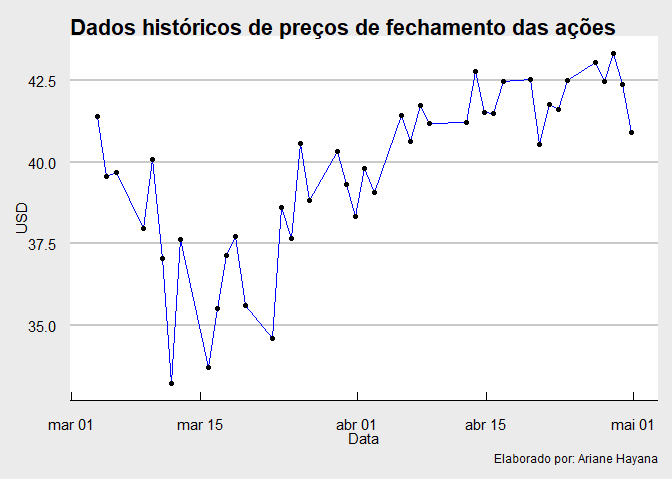

Conforme apresentado na figura acima, há evidências de que a série apresenta bastantes variações, com indícios de não estacionariedade e um comportamento complexo para modelar. Ademais, podemos analisar os gráficos de autocorrelação (ACF) e autocorrelação parcial (PACF) para verificar a estacionariedade da série original:

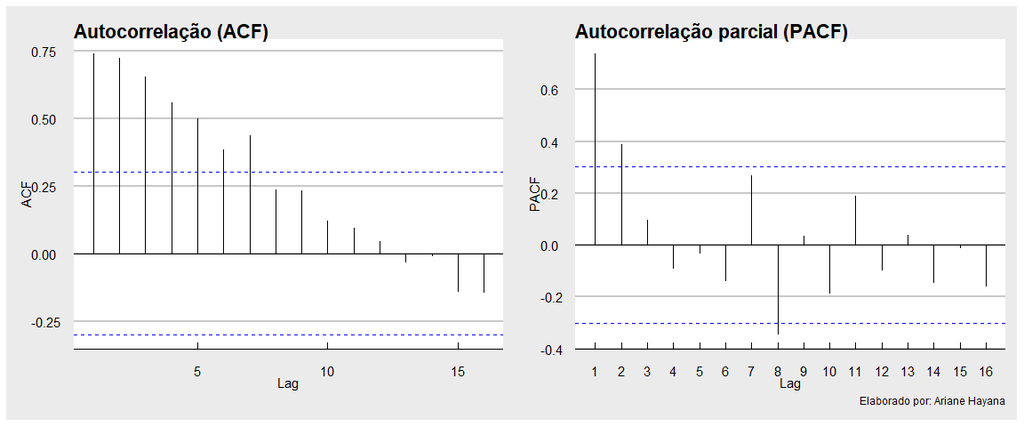

Para estimar a tendência, realizou-se algumas escolhas importantes para o ajuste do modelo. Para tanto, optou-se por realizar o ajuste considerando: (1) uma função linear; (2) uma função polinomial de ordem 5; (3) médias móveis de ordem 5. Ao empilharmos todos os modelos e compararmos em conjunto com a série original, é possível visualizarmos graficamente os diferentes modelos, conforme abaixo:

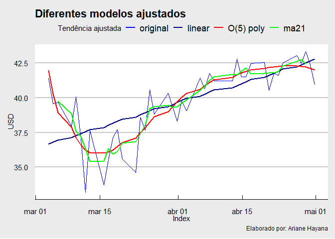

Diante dos resultados obtidos, ao compararmos a série original com os modelos ajustados, é possível notar que tanto o modelo de médias móveis quanto o modelo polinomial estão se ajustando melhor. Assim, neste relatório optou-se por escolher o modelo polinomial de grau cinco.

O passo seguinte consiste em subtrair a tendência estimada (considerando o modelo polinomial de grau cinco) dos dados originais e verificar o comportamento dos resíduos, bem como o gráfico de ACF e PACF.

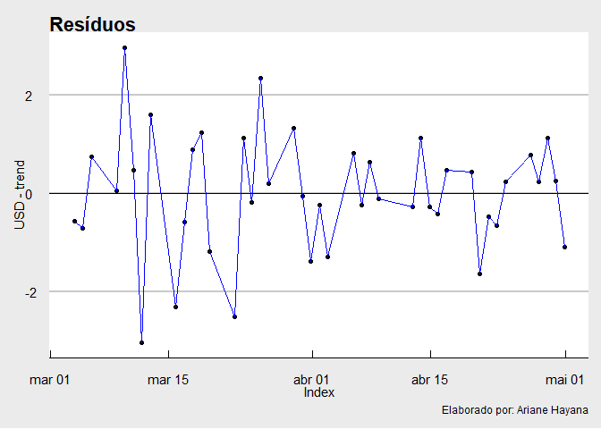

Após retirada a tendência estimada dos dados originais e considerando o polinômio de grau cinco, nota-se no gráfico acima que o comportamento da série sugere que os resíduos têm um comportamento estacionário. Agora, o passo seguinte consiste em verificar graficamente a ACF e PACF:

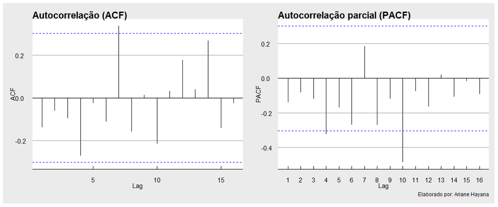

Os gráficos de ACF e PACF indicam que, até mesmo o modelo de polinomial de grau cinco não é apropriado. Percebe-se que na ACF os limites do intervalo de confiança ainda são extrapolados e o comportamento da PACF também não é adequado. Portanto, faz-se necessário partir para uma outra abordagem para um melhor ajuste.

Agora, desconsiderando os modelos anteriores, partiremos para uma nova abordagem, que é a divisão do conjunto de dados em dados de treino e teste. Para tanto, serão alocados 32 dados de treino e 10 de teste. Após esta etapa, é feita uma validação se os dados estão no formato correto e parte-se para a etapa seguinte, que consiste em ajustar um modelo ARIMA.

Utilizando a função `auto_arima()`, é possível encontrar o melhor ajuste através de uma análise comparativa, conforme os resultados obtidos abaixo:

```
 ARIMA(0,1,0)                    : 134.4715
 ARIMA(0,1,0) with drift         : 136.753
 ARIMA(0,1,1)                    : 128.4086
 ARIMA(0,1,1) with drift         : 130.7508
 ARIMA(0,1,2)                    : 129.5682
 ARIMA(0,1,2) with drift         : 132.1684
 ARIMA(0,1,3)                    : 132.2178
 ARIMA(0,1,3) with drift         : 135.0296
 ARIMA(0,1,4)                    : 134.9037
 ARIMA(0,1,4) with drift         : 137.877
 ARIMA(0,1,5)                    : Inf
 ARIMA(0,1,5) with drift         : Inf
 ARIMA(1,1,0)                    : 128.0794
 ARIMA(1,1,0) with drift         : 130.4957
 ARIMA(1,1,1)                    : 129.8294
 ARIMA(1,1,1) with drift         : 132.4015
 ARIMA(1,1,2)                    : 132.2178
 ARIMA(1,1,2) with drift         : 135.0353
 ARIMA(1,1,3)                    : 134.9886
 ARIMA(1,1,3) with drift         : 138.0829
 ARIMA(1,1,4)                    : Inf
 ARIMA(1,1,4) with drift         : Inf
 ARIMA(2,1,0)                    : 129.5882
 ARIMA(2,1,0) with drift         : 132.1668
 ARIMA(2,1,1)                    : Inf
 ARIMA(2,1,1) with drift         : Inf
 ARIMA(2,1,2)                    : 134.9701
 ARIMA(2,1,2) with drift         : 138.0537
 ARIMA(2,1,3)                    : Inf
 ARIMA(2,1,3) with drift         : Inf
 ARIMA(3,1,0)                    : 132.1147
 ARIMA(3,1,0) with drift         : 134.9255
 ARIMA(3,1,1)                    : 134.9128
 ARIMA(3,1,1) with drift         : 137.9894
 ARIMA(3,1,2)                    : Inf
 ARIMA(3,1,2) with drift         : Inf
 ARIMA(4,1,0)                    : 134.9736
 ARIMA(4,1,0) with drift         : 138.0206
 ARIMA(4,1,1)                    : Inf
 ARIMA(4,1,1) with drift         : 141.3562
 ARIMA(5,1,0)                    : 137.4053
 ARIMA(5,1,0) with drift         : 140.7549



 Best model: ARIMA(1,1,0)
```

Note que, dentre os modelos analisados, o melhor modelo foi um ARIMA(1,1,0), o que significa que, com apenas uma diferença resultará em um AR(1).

Podemos verificar o valor do parâmetro autoregressivo, bem como o desvio padrão, além dos critérios de informação de Akaike (AIC), Akaike Corrigido, (AICc) e Bayesiano (BIC) e a log-verossimilhança estimada. Assim, os resultados obtidos foram:

```
Series: detrend_stocks_3M_train
ARIMA(1,1,0)

Coefficients:
          ar1
      -0.4935
s.e.   0.1541

sigma^2 estimated as 3.237:  log likelihood=-61.83
AIC=127.65   AICc=128.08   BIC=130.52
```

O melhor modelo será selecionado considerando o menor valor obtido de AIC ou AICc ou BIC. Desta forma, os resultados apresentam que valor do parâmetro autoregressivo será igual a $-0,4935$ com $AIC = 127,65$, $AICc = 128,08$ e $BIC = 130,52$.

A etapa seguinte consiste na análise dos resíduos, ACF e o teste Ljung-Box, conforme apresentado abaixo:

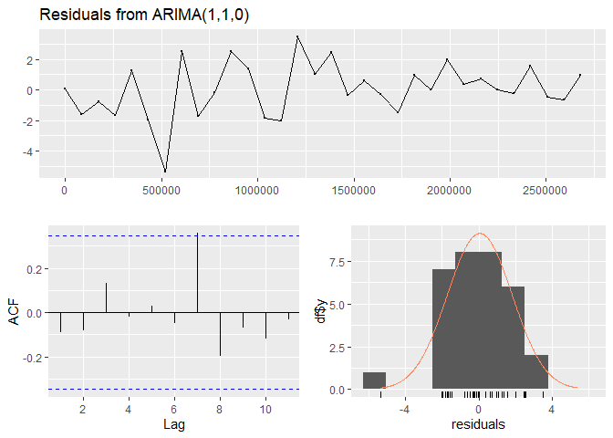

```
    Ljung-Box test

data:  Residuals from ARIMA(1,1,0)
Q* = 1.3259, df = 5, p-value = 0.9322

Model df: 1.   Total lags used: 6
```

$$H_0: \text{tem raiz unitária (não é estacionária)}$$
$$H_1: \text{não tem raiz unitária (é estacionária)}$$

Assim, os resultados obtidos foram:

```
    Augmented Dickey-Fuller Test

data:  detrend_stocks_3M_arima_110_diff
Dickey-Fuller = -7.2389, Lag order = 1, p-value = 0.01
alternative hypothesis: stationary
```

Portanto, com o valor-p igual a $0,01$, rejeitamos $H_0$, o que implica dizer que a série é estacionária a partir da primeira diferença.

Por fim, faz-se uma nova checagem dos resíduos:

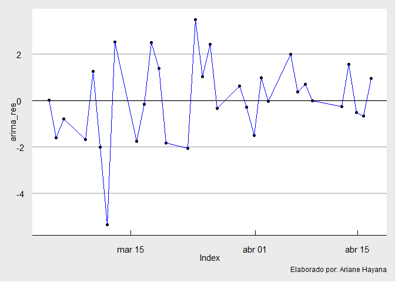

Note que os resíduos apresentam um comportamento estacionário, mesmo com a presença de um ponto que está saindo fora das bandas de confiança. Para os gráficos de ACF e PACF, percebe-se um comportamento apropriado para ambos, conforme exposto na figura abaixo:

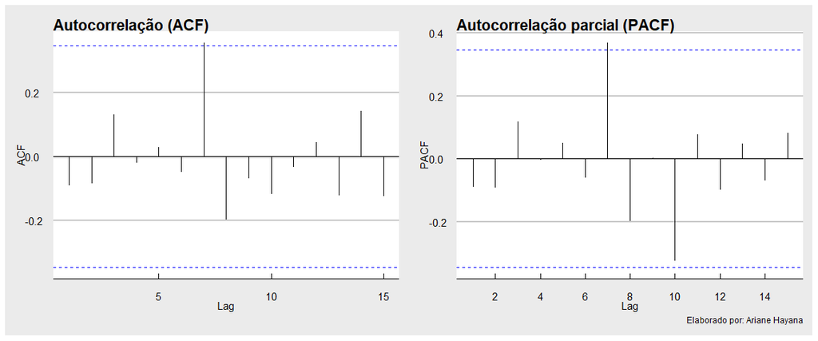

Podemos também verificar as condições apresentadas no círculo unitário, que indica a estabilidade das raízes unitárias do modelo.

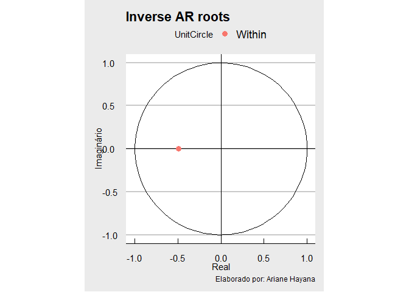

Note que, como estamos analisando um modelo AR(1), reafirmamos através do círculo unitário a ideia de que modelos AR são sempre invertíveis, e, neste caso, a raiz inversa do polinômio nos permite afirmar que o modelo é estacionário por estar dentro do círculo unitário.

## Previsões

Nesta última etapa, serão feitas as previsões em um horizonte de 10 observações ($h = 10$), que serão dispostas na tabela abaixo, apresentando as previsões pontuais (*Point* *Forecast*), os erros, bem como os intervalos de confiança de $80\%$ e $95\%$.

|  | Point_Forecast | Lo80 | Hi80 | Lo95 | Hi95 | observed | errors |
| --- | --- | --- | --- | --- | --- | --- | --- |
| 2764801 | 41.996 | 39.691 | 44.302 | 38.470 | 45.523 | 42.54 | -0.544 |
| 2851201 | 42.235 | 39.650 | 44.820 | 38.282 | 46.188 | 40.55 | 1.685 |
| 2937601 | 42.117 | 39.007 | 45.227 | 37.361 | 46.873 | 41.76 | 0.357 |
| 3024001 | 42.175 | 38.743 | 45.608 | 36.926 | 47.425 | 41.62 | 0.555 |
| 3110401 | 42.147 | 38.364 | 45.929 | 36.362 | 47.931 | 42.52 | -0.373 |
| 3196801 | 42.161 | 38.084 | 46.238 | 35.926 | 48.396 | 43.06 | -0.899 |
| 3283201 | 42.154 | 37.791 | 46.517 | 35.481 | 48.827 | 42.49 | -0.336 |
| 3369601 | 42.157 | 37.531 | 46.784 | 35.082 | 49.233 | 43.34 | -1.183 |
| 3456001 | 42.156 | 37.277 | 47.034 | 34.695 | 49.616 | 42.38 | -0.224 |
| 3542401 | 42.156 | 37.040 | 47.273 | 34.332 | 49.981 | 40.92 | 1.236 |

Assim, os resultados obtidos podem ser representados graficamente, conforme abaixo:

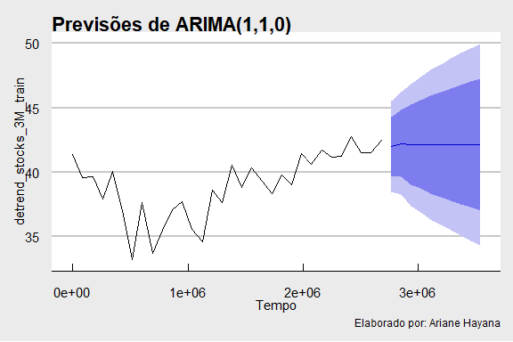

Note que, as informações não estão adequadamente apresentadas, portanto, no gráfico a seguir faz-se uma versão aprimorada dos resultados gráficos:

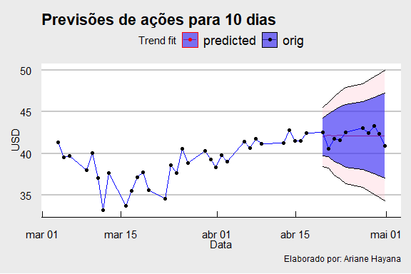

Perceba que, neste último gráfico as informações estão melhor apresentadas visualmente. Nele é possível observar o valor dos dados originais, bem como os valores preditos (*linha em vermelho*) do modelo e os intervalos de confiança de $80\%$ e $95\%$ no lado direito do gráfico.

## Conclusões

Este relatório apresentou uma análise de séries temporais com objetivo de construir um modelo de previsão de preços de fechamento de ações do mercado financeiro considerando 42 observações diárias.

Alguns modelos foram ajustados e, dentre os resultados obtidos, foi possível encontrar o melhor modelo através de uma análise comparativa entre diversos resultados utilizando a função `auto_arima()` do *software* estatístico `R` para seleção do modelo. Desta forma, obteve-se como resultado o modelo ARIMA(1,1,0), o que implica que com apenas uma diferença, o resultado será um modelo AR(1). Assim, fez-se as devidas análises e validações, o que findou em um modelo de previsões adequado.

Por fim, ressalta-se que o exemplo aplicado neste relatório é didático. A volatilidade no mercado financeiro em um cenário real é mais complexa e está relacionada a diversos fatores, o que requer um entendimento maior no mercado de ações.